# Untitled

## 2.1 Biofilm formation

In this study we employ a multispecies oral biofilm model following a modified protocol from Sissons and colleagues (1991) and Shellis (1978). The setup comprises a polypropylene 24 deepwell PCR plate (KingFisher 97003510) with a lid containing 24 pegs (substrata), which is autoclaved at 120°C, 1 bar overpressure, for 20 mins.

The artificial saliva (AS) is a modified version of the basal medium mucin (BMM) described by Sissons and colleagues (1991). It contains 2.5 g/l partially purified mucin from porcine stomach (Type III, Sigma M1778), 5 g/l trypticase peptone (Roth 2363.1), 10 g/l proteose peptone (Oxoid LP0085), 5 g/l yeast extract (BD 211921), 2.5 g/l KCl, 0.35 g/l NaCl, 1.8 mmol/l CaCl<sub>2</sub>, 5.2 mmol/l Na<sub>2</sub>HPO<sub>4</sub> (Sissons et al., 1991), 6.4 mmol/l NaHCO<sub>3</sub> (Shellis, 1978), 2.5 mg/l haemin. This is subsequently adjusted to pH 7 with NaOH pellets and stirring, autoclaved (15 min, 120°C, 1 bar overpressure), and supplemented with 5.8 $\mu$mol/l menadione, 5 mmol/l urea, and 1 mmol/l arginine (Sissons et al., 1991).

Fresh whole saliva (WS) for inoculation was provided by a 31-year-old male donor with no history of caries, who abstained from oral hygiene for 24 hours, and no food was consumed two hours prior to donation. No antibiotics were taken up to six months prior to donation. The saliva was filtered through a sterilised (with bleach) nylon cloth to remove particulates. Substrata were inoculated with 1 ml/well of a two-fold dilution of WS in sterilised 20% glycerine for four hours at 36°C, to allow attachment of the salivary pellicle and plaque-forming bacteria. After initial inoculation, the substrata were transferred to a new plate containing 1 ml/well AS and incubated at 36°C, 30 rpm. The inoculation process was repeated on days 3 and 5. AS was partially refreshed once per day and fully refreshed every three days, throughout the experiment, by transferring the substrata to a new plate containing AS. To feed the bacteria, the substrata were transferred to a new plate, containing 5% (w/v) sucrose, for six minutes twice daily, except on inoculation days (days 0, 3, and 5), where the samples only received one sucrose treatment after inoculation.

All laboratory work was conducted in sterile conditions under a laminar flow hood to prevent starch and bacterial contamination. Control samples were included to detect starch contamination.

## 2.3 Starch counts

Starch granule counts were divided into three size categories: small (<10 $\mu$m), medium (10 – 20 $\mu$m), and large (>20 $\mu$m). Counts for small wheat and potato starches were combined for the mixed treatment samples, as it is not possible to distinguish the small starch granules between the two species.

### 2.3.1 Treatment solutions

A 1 ml aliquot of each starch solution was taken, from which 10 $\mu$l was mounted on a microscope slide with an 18 x 18 mm coverslip, and counted under a light microscope (Zeiss Axioscope A1). Counting starches on a full slide was not feasible, so three slide transects were counted (at 1/3, 1/2, and 2/3 of the slide), and the sample counts were extrapolated (see Supplementary material for more details).

### 2.3.2 Extraction from samples

Extraction of starches from the calculus samples was performed by dissolving the calculus in ethylenediaminetetraacetic acid (EDTA), as it has been shown to have little to no effect on starch granules (especially native granules) (Le Moyne & Crowther, 2021; Modi et al., 2020; Tromp et al., 2017), and vortexing for 3 days until the sample was completely dissolved. Twenty $\mu$l of sample was mounted onto a slide with an 18x18 mm coverslip. When dispersing the liquid (EDTA) sample on the slide, the sample was homogenised using the pipette. It was not possible to count all wheat starches on a slide, so wheat and mix counts were extrapolated as described for the treatment solutions.

## 2.4 Statistical analysis

Statistical analysis was conducted in R versions 4.0.5 (“Shake and Throw”) and 4.0.3 (“Bunny-Wunnies Freak Out”) (R Core Team, 2020). A one-way ANOVA with sample weight as the dependent variable (DV) and treatment as the grouping variable (GV) was conducted to explore the effect of the different starch treatments on biofilm growth.

To calculate size proportions, mean counts for each treatment were taken across both experimental plates for each treatment, resulting in a mean count for each granule size category within each treatment.

Pearson’s r was conducted on sample weight and total starch count, as well as sample weight and starch count per mg calculus. The total count for each sample within a treatment was standardised by z-score to account for the differences in magnitude between the potato and wheat counts.

Scripts and data will be made available on osf.io upon publication. Until then, they can be found on the first author’s GitHub repository (https://github.com/bbartholdy/byocStarch).

# 3 Results

All samples yielded sufficient biofilm growth and starch incorporation to be included in the analysis, resulting in a total of 48 biofilm samples (two plates of 24), 45 of which were used for analysis (three samples were set aside for separate analysis). Most control samples contained no starch granules, while some contained negligible quantities (supp. mat).

## 3.2 Treatment type had no effect on biofilm growth

Table 3.1: Summary statistics for biofilm dry-weights (in mg) by treatment.

| Treatment | Mean | SD | Min | Max |
| --- | --- | --- | --- | --- |
| control | 5.44 | 2.45 | 1.67 | 11.20 |
| mix | 4.28 | 1.95 | 1.50 | 8.44 |
| potato | 6.25 | 2.07 | 2.54 | 8.92 |
| wheat | 5.53 | 3.45 | 0.56 | 9.80 |

[output not shown]

## 3.3 Starch counts

Table 3.2: Mean starch counts from solutions, including the proportional makeup of the different sizes of granules.

| Solution | Starch | Small (%) | Medium (%) | Large (%) | Total (%) |
| --- | --- | --- | --- | --- | --- |
| mix | potato | NaN (NA) | 1051733 (53.1%) | 928000 (46.9%) | 1979733 (100.0%) |
| mix | wheat | 18838400 (69.7%) | 6403200 (23.7%) | 1794133 (6.6%) | 27035733 (100.0%) |
| mix | both | 18838400 (64.9%) | 7454933 (25.7%) | 2722133 (9.4%) | 29015467 (100.0%) |
| potato | potato | 123733 (4.1%) | 1337867 (44.4%) | 1554400 (51.5%) | 3016000 (100.0%) |
| wheat | wheat | 16139467 (63.5%) | 6434133 (25.3%) | 2830400 (11.1%) | 25404000 (100.0%) |

Table 3.3: Mean starch counts extracted from samples with standard deviation (SD), including the proportion of granule sizes of the total count.

| Treatment | Starch | Small (%) | SD | Medium (%) | SD | Large (%) | SD | Total (%) | SD |
| --- | --- | --- | --- | --- | --- | --- | --- | --- | --- |
| mix | potato | NaN (NA) | NA | 1959 (79.6%) | 1800 | 501 (20.40%) | 446 | 2460 (100%) | 2190 |
| mix | wheat | 9515 (54.60%) | 8860 | 6522 (37.4%) | 6030 | 1381 (7.93%) | 1200 | 17417 (100%) | 15900 |
| mix | both | 9515 (47.90%) | 8860 | 8480 (42.7%) | 7650 | 1882 (9.47%) | 1600 | 19877 (100%) | 17800 |
| potato | potato | 351 (7.24%) | 297 | 3565 (73.6%) | 2400 | 930 (19.20%) | 929 | 4846 (100%) | 3320 |
| wheat | wheat | 15235 (55.00%) | 11900 | 12148 (43.9%) | 11100 | 1953 (7.06%) | 2020 | 27680 (100%) | 23600 |

It was not possible to differentiate between potato and wheat starches smaller than ca. 10 $\mu$m, small potato starches were counted as wheat starches in the mixed-treatment samples. This is reasonable given that the small potato granules make up an insignificant proportion of the total count of small granules within mixed-treatment solutions which are predominantly wheat granules (99.2%).

The separate wheat and potato solutions were made with a 0.25% (w/v) starch concentration, while the mixed-starch solution was made with 0.25% (w/v) of each starch, with a total concentration of 0.50% (w/v). The mixed-treatment had the highest absolute count of starch granules in solution, while the biofilms exposed to the wheat solution preserved the greatest number of granules. The potato treatment had the lowest absolute counts in both the solution and in the biofilm samples (Tables 3.2 and 3.3).

### 3.3.1 Proportion of available starches incorporated in samples

Table 3.4: The mean percentage of starches from the solutions that were incorported into the samples.

| Treatment | Starch | Small | Medium | Large | Total |
| --- | --- | --- | --- | --- | --- |
| mix | potato | NA | 0.186% | 0.054% | 0.124% |
| mix | wheat | 0.051% | 0.102% | 0.077% | 0.064% |
| mix | both | 0.051% | 0.114% | 0.069% | 0.069% |
| potato | potato | 0.284% | 0.266% | 0.060% | 0.161% |
| wheat | wheat | 0.094% | 0.189% | 0.069% | 0.109% |

The proportion of total starches from the solutions that were incorporated into the samples ranged from 0.064% to 0.161%, with potato granules being more readily incorporated than wheat in both the separated- and mixed-treatment samples (Table 3.4). There is an inverse relationship between the absolute starch count in the solutions and the proportional incorporation of starches in the biofilm samples, i.e. potato had the lowest absolute count in solutions, but the highest proportional incorporation, and vice versa for the mixed treatment.

### 3.3.2 Size ratios differ between solutions and samples

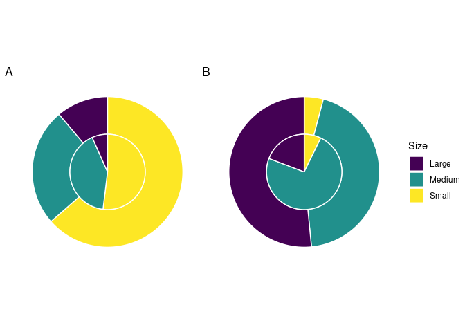

Figure 3.1: (A) Proportion (%) of sizes of starch granules in the wheat solution (outer ring) and extracted from the wheat-treatment samples (inner ring), and (B) in the potato solution (outer ring) and extracted from the potato-treatment samples (inner ring). l = large, m = medium, s = small.

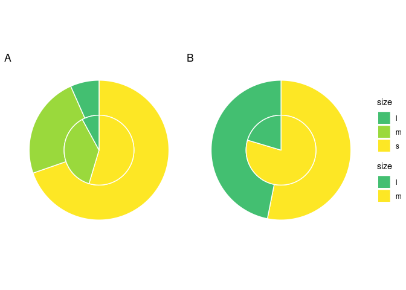

Overall, medium starch granules had a higher mean rate of incorporation (0.186%) than small (0.143%) and large (0.065%) starch granules across all treatments, while large potato starches had the lowest rate of incorporation across all treatments.

The difference in incorporation between the size categories resulted in a change in size ratios between the original starch solutions and the extracted samples. Large potato granules (> 20 $\mu$m) were most affected, with a 32.3% decrease in relative abundance in the potato-only treatment, and a 26.5% decrease in mixed treatments. Medium granules increased in relative abundance across all samples, while small granules decreased in wheat treatments and increased in potato treatments (Figures 3.1 and 3.2).

### 3.3.3 Biofilm weight correlated positively with extracted starch counts

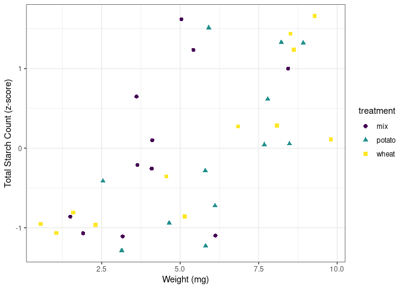

Figure 3.3: Scatter plot of sample weight and standardised starch count by Z-score for seprated treatments.

Pearson’s *r* suggests a strong positive correlation between the total weight of the biofilms and the total starch count (standardised by z-score) extracted from the samples across treatments, *r* = 0.659, 90%CI[0.463, 0.794], p = < 0.001 (Figure 3.3).

The same test was applied to total biofilm weight and starch count per mg calculus (also standardised by z-score), resulting in a weak positive correlation, *r* = 0.3, 90%CI[0.0618, 0.506], p 0.0403 (Figure 3.4).

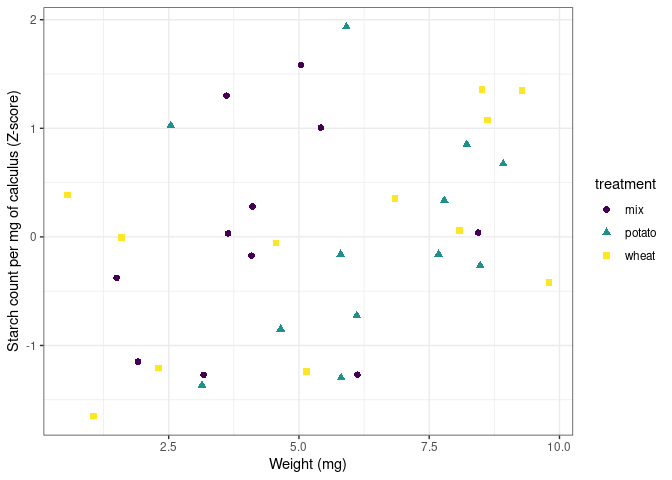

Figure 3.4: Scatter plot of sample weight in mg and standardised count of starch grains per mg calculus.

# 4 Discussion

Here, we have provided a method for exploring the incorporation of dietary starches into the mineral matrix of a dental calculus biofilm model. Our results show that a very low proportion of the starches exposed to the biofilm during growth are retained in the mineral matrix, and that the size of the starch granules may affect the likeliness of incorporation. The proportions of starch granules (of all sizes) present in the extracted samples were similar across all treatments (0.064% to 0.161%), despite large differences in absolute granule counts between wheat (25,404,000) and potato (3,016,000) solutions.  
The absolute counts, however, differed more visibly between treatments and was proportional with the total count of granules in the treatment solutions. Wheat and mixed solutions had the highest absolute mean count of starch granules, and also had the highest absolute mean count of starch granules extracted from the dental calculus (Tables 3.2 and 3.3). This suggests that the starches that are more frequently consumed will be present in higher quantities in the dental calculus, at least prior to inhumation and degradation in the burial environment; although, starch availability is unlikely to be a main factor in starch incorporation. Despite the low proportion of granules recovered from the model calculus (0.064% to 0.161%), the absolute counts were still substantially greater than counts recovered from archaeological remains (Tromp et al., 2017; Tromp & Dudgeon, 2015; Wesolowski et al., 2010).

Previous research conducted on dental calculus from contemporary humans and non-human primates suggest a high level of stochasticity involved in the retention of starch granules in dental calculus, and that starch granules extracted from dental calculus are underrepresented with regard to actual starch intake, which is consistent with our findings (illustrated by high standard deviations and low proportional incorporation). Leonard and colleagues (2015) found individual calculus samples to be a poor predictor of diet in a population, as many of the consumed plants were missing from some individual samples, but were present in others.  
Power and colleagues (2015) presented similar findings in non-human primates, where phytoliths were more representative of individual diets than starch granules, and plants that produce predominantly larger starch (10-20 $\mu$m) granules were over-represented. Both studies concluded that the dietary breadth of a population can be captured in a sufficiently large sample, but interpretations on individual diets from microremains in dental calculus is tenuous, at best (Leonard et al., 2015; Power et al., 2015).

Additionally, the size of the calculus deposit seems to influence the quantity of starches extracted from the calculus, as we found a strong positive correlation between biofilm size and retained starch granules (Figure 3.3), which contradicts findings from archaeological contexts (Dudgeon & Tromp, 2014; Wesolowski et al., 2010). When the concentration of starch granules per mg calculus is considered, the correlation is weaker, but still present (Figure 3.4); while the larger deposits contain a higher absolute count, our findings also suggest that they contain a slightly higher concentration of starches. The lack of a correlation in archaeological contexts could be due to diagenetic effects; or, the absence of amylase activity in our study could be impacting our interpretations.

The mechanism by which starch granules are incorporated into plaque and calculus remains largely unknown, and few studies have directly investigated potential mechanisms. We know that a proportion of the starch granules entering the mouth can become trapped in the plaque/calculus, and can be recovered from archaeological samples of significant age (Buckley et al., 2014; Henry et al., 2014; Wu et al., 2021). Studies have also shown that not all starch granules come from a dietary source. Other pathways include cross-contamination from plant interactions in soil, such as palm phytoliths adhering to the skin of sweet potatoes (Tromp & Dudgeon, 2015), or accidental ingestion not related to food consumption (Radini et al., 2019; Radini et al., 2017).

This article presents preliminary research exploring the potential of an oral biofilm model for dietary research in archaeology. A limitation of this study is the absence of amylase in the model. The presence of amylase will likely affect the total granule counts as well as the size ratios, as smaller starches may be more susceptible to hydrolysis (Franco et al., 1992; Haslam, 2004). In future experiments, we recommend the addition of $\alpha$-amylase to the model in concentrations similar to those found in the oral cavity While we are able to show the differing incorporation caused by absolute counts available, this was merely a side-effect of the difference in the number of granules in potato and wheat solutions of the same concentration (w/v). Further research should test multiple differing concentrations of the same starch type. The use of EDTA may also have affected counts. While previous studies have shown negligible morphological changes caused by exposure to EDTA (Le Moyne & Crowther, 2021; Modi et al., 2020; Tromp et al., 2017), these studies have not considered changes to separate size categories within starch types, and whether shifts in size ratios occur due to exposure to the pre-treatment chemicals. The total number of granules on a slide often exceeded a number that was feasible to count in a reasonable time period, so we calculated the total counts by extrapolating from three slide transects. Thus, we reasonably assume that the three transects are a good representation of the entire slide, and that the distribution of all granules on the slide is relatively homogenous.  
Finally, we only used native starches in the experimental procedure and the results will likely differ for processed starches (García-Granero, 2020). Based on counts obtained by Leonard and colleagues (2015, Supplement 2), processing and amylase may have a substantial effect on starch granule retention in the oral cavity.

The oral biofilm model described in this study, and in Bartholdy and colleagues (in prep.), provides a method to directly explore the incorporation and extraction of dietary compounds from dental calculus in a controlled laboratory setting. The addition of known species in separate samples also removes the identification bias against the smaller undiagnostic starches. It can also address the call for more baseline testing of biases associated with dietary research conducted on dental calculus (Le Moyne & Crowther, 2021). *In vivo* studies on humans and non-human primates will be limited by the variability occurring between individuals, and difficulties documenting the entirety of starch granules entering the oral cavity at any given moment, especially accidental intake. Our experimental setup allows us a higher degree of control over the factors that influence starch incorporation, such as dietary intake, processing of starches leading to differential survivability, and inter- and intra-individual variation in plaque accumulation and mineralisation. The latter is especially difficult to control *in vivo* as it is influenced by numerous factors including genetics, diet, and tooth morphology (Jepsen et al., 2011).  
Further research is necessary to explore the mechanisms of the intra-oral starch incorporation and retention in dental calculus, and the dental calculus model presented in this study is uniquely suited to explore these questions and may improve interpretations of dietary research in past populations.

# 5 Conclusions

Our preliminary study shows that a very small proportion of the ingested starch granules are retained in a dental calculus model.

Given the direct proportional incorporation of starches with quantity of exposure, we can say that the proportion of starches consumed will in many cases be reflected in the quantity of starches extracted from the dental calculus, at least in modern calculus samples unaffected by diagenesis. Whether or not this also applies to archaeological samples remains to be tested.

The size of calculus deposit also influences the maximum capacity of granule incorporation; as the size of the deposit increases, so does the absolute count of incorporated granules.

The data from this study are not sufficient to confirm or deny any proposed methods of starch incorporation; however, while we are unable to address the mechanism(s) of starch incorporation with the current experimental setup, this is something that can potentially be addressed with the calculus model presented in this paper.

While we have shown multiple factors that influence the likelihood of incorporation, it seems the process is somewhat stochastic, and possibly related to the biofilm mineralisation events (as discussed above), which are irregular and related to various factors. This means that the dietary components extracted from dental calculus provide a snapshot of the diet around the time of the mineralisation event, which may not be an accurate picture of the diet as a whole.

The dental calculus biofilm model presented in this study is a powerful tool to investigate various aspects of dietary research.

# References cited

Adler, C. J., Dobney, K., Weyrich, L. S., Kaidonis, J., Walker, A. W., Haak, W., Bradshaw, C. J., Townsend, G., Soltysiak, A., Alt, K. W., Parkhill, J., & Cooper, A. (2013). Sequencing ancient calcified dental plaque shows changes in oral microbiota with dietary shifts of the Neolithic and Industrial revolutions. *Nature Genetics*, *45*(4), 450–455, 455e1. https://doi.org/10.1038/ng.2536

Armitage, P. L. (1975). The Extraction and Identification of Opal Phytoliths from the Teeth of Ungulates. *Journal of Archaeological Science*, *2*, 187–197.

Björck, I., Asp, N.-G., Birkhed, D., Eliasson, A.-C., Sjöberg, L.-B., & Lundquist, I. (1984). Effects of processing on starch availability In vitro and In vivo. II. Drum-drying of wheat flour. *Journal of Cereal Science*, *2*(3), 165–178. https://doi.org/10.1016/S0733-5210(84)80030-2

Buckley, S., Usai, D., Jakob, T., Radini, A., & Hardy, K. (2014). Dental Calculus Reveals Unique Insights into Food Items, Cooking and Plant Processing in Prehistoric Central Sudan. *PLOS ONE*, *9*(7), e100808. https://doi.org/10.1371/journal.pone.0100808

Cummings, L. S., & Magennis, A. (1997). A phytolith and starch record of food and grit in Mayan human tooth tartar. In A. Pinilla, J. Juan-Tresserras, & M. J. Machado (Eds.), *The State-of-the-Art of Phytoliths in Soils and Plants*. CSIC Press. http://books.google.com?id=j66CDVfVhwEC

Dudgeon, J. V., & Tromp, M. (2014). Diet, Geography and Drinking Water in Polynesia: Microfossil Research from Archaeological Human Dental Calculus, Rapa Nui (Easter Island). *International Journal of Osteoarchaeology*, *24*(5), 634–648. https://doi.org/10.1002/oa.2249

Eerkens, J. W., Tushingham, S., Brownstein, K. J., Garibay, R., Perez, K., Murga, E., Kaijankoski, P., Rosenthal, J. S., & Gang, D. R. (2018). Dental calculus as a source of ancient alkaloids: Detection of nicotine by LC-MS in calculus samples from the Americas. *Journal of Archaeological Science: Reports*, *18*, 509–515. https://doi.org/10.1016/j.jasrep.2018.02.004

Fox, C. L., Juan, J., & Albert, R. M. (1996). Phytolith analysis on dental calculus, enamel surface, and burial soil: Information about diet and paleoenvironment. *American Journal of Physical Anthropology*, *101*(1), 101–113. https://doi.org/10.1002/(SICI)1096-8644(199609)101:1<101::AID-AJPA7>3.0.CO;2-Y

Franco, C. M. L., Preto, S. J. do R., & Ciacco, C. F. (1992). Factors that Affect the Enzymatic Degradation of Natural Starch Granules -Effect of the Size of the Granules. *Starch - Stärke*, *44*(11), 422–426. https://doi.org/10.1002/star.19920441106

García-Granero, J. J. (2020). Starch taphonomy, equifinality and the importance of context: Some notes on the identification of food processing through starch grain analysis. *Journal of Archaeological Science*, *124*, 105267. https://doi.org/10.1016/j.jas.2020.105267

Gismondi, A., D’Agostino, A., Canuti, L., Di Marco, G., Basoli, F., & Canini, A. (2019). Starch granules: A data collection of 40 food species. *Plant Biosystems - An International Journal Dealing with All Aspects of Plant Biology*, *153*(2), 273–279. https://doi.org/10.1080/11263504.2018.1473523

Hardy, K., Blakeney, T., Copeland, L., Kirkham, J., Wrangham, R., & Collins, M. (2009). Starch granules, dental calculus and new perspectives on ancient diet. *Journal of Archaeological Science*, *36*(2), 248–255. https://doi.org/10.1016/j.jas.2008.09.015

Hardy, K., Buckley, S., Collins, M. J., Estalrrich, A., Brothwell, D., Copeland, L., García-Tabernero, A., García-Vargas, S., de la Rasilla, M., Lalueza-Fox, C., Huguet, R., Bastir, M., Santamaría, D., Madella, M., Wilson, J., Cortés, Á. F., & Rosas, A. (2012). Neanderthal medics? Evidence for food, cooking, and medicinal plants entrapped in dental calculus. *Naturwissenschaften*, *99*(8), 617–626. https://doi.org/10.1007/s00114-012-0942-0

Haslam, M. (2004). The decomposition of starch grains in soils: Implications for archaeological residue analyses. *Journal of Archaeological Science*, *31*(12), 1715–1734. https://doi.org/10.1016/j.jas.2004.05.006

Hendy, J., Warinner, C., Bouwman, A., Collins, M. J., Fiddyment, S., Fischer, R., Hagan, R., Hofman, C. A., Holst, M., Chaves, E., Klaus, L., Larson, G., Mackie, M., McGrath, K., Mundorff, A. Z., Radini, A., Rao, H., Trachsel, C., Velsko, I. M., & Speller, C. F. (2018). Proteomic evidence of dietary sources in ancient dental calculus. *Proceedings. Biological Sciences*, *285*(1883), 20180977. https://doi.org/10.1098/rspb.2018.0977

Henry, A. G., Brooks, A. S., & Piperno, D. R. (2014). Plant foods and the dietary ecology of Neanderthals and early modern humans. *Journal of Human Evolution*, *69*, 44–54. https://doi.org/10.1016/j.jhevol.2013.12.014

Henry, A. G., Hudson, H. F., & Piperno, D. R. (2009). Changes in starch grain morphologies from cooking. *Journal of Archaeological Science*, *36*(3), 915–922. https://doi.org/10.1016/j.jas.2008.11.008

Henry, A. G., & Piperno, D. R. (2008). Using plant microfossils from dental calculus to recover human diet: A case study from Tell al-Raqā’i, Syria. *Journal of Archaeological Science*, *35*(7), 1943–1950. https://doi.org/10.1016/j.jas.2007.12.005

Jepsen, S., Deschner, J., Braun, A., Schwarz, F., & Eberhard, J. (2011). Calculus removal and the prevention of its formation. *Periodontology 2000*, *55*(1), 167–188. https://doi.org/10.1111/j.1600-0757.2010.00382.x

Jin, Y., & Yip, H.-K. (2002). Supragingival Calculus: Formation and Control: *Critical Reviews in Oral Biology & Medicine*. https://doi.org/10.1177/154411130201300506

Jovanović, J., Power, R. C., de Becdelièvre, C., Goude, G., & Stefanović, S. (2021). Microbotanical evidence for the spread of cereal use during the Mesolithic-Neolithic transition in the Southeastern Europe (Danube Gorges): Data from dental calculus analysis. *Journal of Archaeological Science*, *125*, 105288. https://doi.org/10.1016/j.jas.2020.105288

Kashket, S., Zhang, J., & Houte, J. V. (1996). Accumulation of Fermentable Sugars and Metabolic Acids in Food Particles that Become Entrapped on the Dentition. *Journal of Dental Research*, 8.

Klepinger, L. L., Kuhn, J. K., & Thomas, J. (1977). Prehistoric dental calculus gives evidence for coca in early coastal Ecuador. *Nature*, *269*(5628, 5628), 506–507. https://doi.org/10.1038/269506a0

Le Moyne, C., & Crowther, A. (2021). Effects of chemical pre-treatments on modified starch granules: Recommendations for dental calculus decalcification for ancient starch research. *Journal of Archaeological Science: Reports*, *35*, 102762. https://doi.org/10.1016/j.jasrep.2020.102762

Leonard, C., Vashro, L., O’Connell, J. F., & Henry, A. G. (2015). Plant microremains in dental calculus as a record of plant consumption: A test with Twe forager-horticulturalists. *Journal of Archaeological Science: Reports*, *2*, 449–457. https://doi.org/10.1016/j.jasrep.2015.03.009

Lingstrom, P., Birkhed, D., Ruben, J., & Arends, J. (1994). Effect of Frequent Consumption of Starchy Food Items on Enamel and Dentin Demineralization and on Plaque pH in situ. *Journal of Dental Research*, *73*(3), 652–660. https://doi.org/10.1177/00220345940730031101

Mickleburgh, H. L., & Pagán-Jiménez, J. R. (2012). New insights into the consumption of maize and other food plants in the pre-Columbian Caribbean from starch grains trapped in human dental calculus. *Journal of Archaeological Science*, *39*(7), 2468–2478. https://doi.org/10.1016/j.jas.2012.02.020

Middleton, W. D., & Rovner, I. (1994). Extraction of Opal Phytoliths from Herbivore Dental Calculus. *Journal of Archaeological Science*, *21*(4), 469–473. https://doi.org/10.1006/jasc.1994.1046

Modi, A., Pisaneschi, L., Zaro, V., Vai, S., Vergata, C., Casalone, E., Caramelli, D., Moggi-Cecchi, J., Mariotti Lippi, M., & Lari, M. (2020). Combined methodologies for gaining much information from ancient dental calculus: Testing experimental strategies for simultaneously analysing DNA and food residues. *Archaeological and Anthropological Sciences*, *12*(1), 10. https://doi.org/10.1007/s12520-019-00983-5

Nikitkova, A. E., Haase, E. M., & Scannapieco, F. A. (2013). Taking the Starch out of Oral Biofilm Formation: Molecular Basis and Functional Significance of Salivary α-Amylase Binding to Oral Streptococci. *Applied and Environmental Microbiology*, *79*(2), 416–423. https://doi.org/10.1128/AEM.02581-12

Pearce, E. I. F., & Sissons, C. H. (1987). The Concomitant Deposition of Strontium and Fluoride in Dental Plaque. *Journal of Dental Research*, *66*(10), 1518–1522. https://doi.org/10.1177/00220345870660100101

Piperno, D. R., & Dillehay, T. D. (2008). Starch grains on human teeth reveal early broad crop diet in northern Peru. *Proceedings of the National Academy of Sciences*, *105*(50), 19622–19627. https://doi.org/10.1073/pnas.0808752105

Power, R. C., Salazar-Garcia, D. C., Wittig, R. M., Freiberg, M., & Henry, A. G. (2015). Dental calculus evidence of Tai Forest Chimpanzee plant consumption and life history transitions. *Scientific Reports*, *5*, 15161. https://doi.org/10.1038/srep15161

Power, R. C., Salazar-García, D. C., Wittig, R. M., & Henry, A. G. (2014). Assessing use and suitability of scanning electron microscopy in the analysis of micro remains in dental calculus. *Journal of Archaeological Science*, *49*, 160–169. https://doi.org/10.1016/j.jas.2014.04.016

R Core Team. (2020). *R: A language and environment for statistical computing* [Manual]. R Foundation for Statistical Computing. https://www.R-project.org/

Radini, A., Nikita, E., Buckley, S., Copeland, L., & Hardy, K. (2017). Beyond food: The multiple pathways for inclusion of materials into ancient dental calculus. *American Journal of Physical Anthropology*, *162*, 71–83. https://doi.org/10.1002/ajpa.23147

Radini, A., Tromp, M., Beach, A., Tong, E., Speller, C., McCormick, M., Dudgeon, J. V., Collins, M. J., Rühli, F., Kröger, R., & Warinner, C. (2019). Medieval women’s early involvement in manuscript production suggested by lapis lazuli identification in dental calculus. *Science Advances*, *5*(1), eaau7126. https://doi.org/10.1126/sciadv.aau7126

Shellis, R. P. (1978). A synthetic saliva for cultural studies of dental plaque. *Archives of Oral Biology*, *23*(6), 485–489. https://doi.org/10.1016/0003-9969(78)90081-X

Sissons, C. H., Cutress, T. W., Hoffman, M. P., & Wakefield, J. S. J. (1991). A Multi-station Dental Plaque Microcosm (Artificial Mouth) for the Study of Plaque Growth, Metabolism, pH, and Mineralization: *Journal of Dental Research*. https://doi.org/10.1177/00220345910700110301

Tan, B., Gillam, D. G., Mordan, N. J., & Galgut, P. N. (2004). A preliminary investigation into the ultrastructure of dental calculus and associated bacteria. *Journal of Clinical Periodontology*, *31*(5), 364–369. https://doi.org/10.1111/j.1600-051X.2004.00484.x

Tan, B. T. K., Mordan, N. J., Embleton, J., Pratten, J., & Galgut, P. N. (2004). Study of Bacterial Viability within Human Supragingival Dental Calculus. *Journal of Periodontology*, *75*(1), 23–29. https://doi.org/10.1902/jop.2004.75.1.23

Tao, D., Zhang, G., Zhou, Y., & Zhao, H. (2020). Investigating wheat consumption based on multiple evidences: Stable isotope analysis on human bone and starch grain analysis on dental calculus of humans from the Laodaojing cemetery, Central Plains, China. *International Journal of Osteoarchaeology*, *30*(5), 594–606. https://doi.org/10.1002/oa.2884

Tromp, M., Buckley, H., Geber, J., & Matisoo-Smith, E. (2017). EDTA decalcification of dental calculus as an alternate means of microparticle extraction from archaeological samples. *Journal of Archaeological Science: Reports*, *14*, 461–466. https://doi.org/10.1016/j.jasrep.2017.06.035

Tromp, M., & Dudgeon, J. V. (2015). Differentiating dietary and non-dietary microfossils extracted from human dental calculus: The importance of sweet potato to ancient diet on Rapa Nui. *Journal of Archaeological Science*, *54*, 54–63. https://doi.org/10.1016/j.jas.2014.11.024

Warinner, C., Hendy, J., Speller, C., Cappellini, E., Fischer, R., Trachsel, C., Arneborg, J., Lynnerup, N., Craig, O. E., Swallow, D. M., Fotakis, A., Christensen, R. J., Olsen, J. V., Liebert, A., Montalva, N., Fiddyment, S., Charlton, S., Mackie, M., Canci, A., … Collins, M. J. (2014). Direct evidence of milk consumption from ancient human dental calculus. *Scientific Reports*, *4*, 7104. https://doi.org/10.1038/srep07104

Warinner, C., Rodrigues, J. F., Vyas, R., Trachsel, C., Shved, N., Grossmann, J., Radini, A., Hancock, Y., Tito, R. Y., Fiddyment, S., Speller, C., Hendy, J., Charlton, S., Luder, H. U., Salazar-Garcia, D. C., Eppler, E., Seiler, R., Hansen, L. H., Castruita, J. A., … Cappellini, E. (2014). Pathogens and host immunity in the ancient human oral cavity. *Nature Genetics*, *46*(4), 336–344. https://doi.org/10.1038/ng.2906

Wesolowski, V., Ferraz Mendonça de Souza, S. M., Reinhard, K. J., & Ceccantini, G. (2010). Evaluating microfossil content of dental calculus from Brazilian sambaquis. *Journal of Archaeological Science*, *37*(6), 1326–1338. https://doi.org/10.1016/j.jas.2009.12.037

Wu, Y., Tao, D., Wu, X., & Liu, W. (2021). *Diet of the earliest modern humans in East Asia* [Preprint]. In Review. https://doi.org/10.21203/rs.3.rs-442096/v1